# Regression

Anna Wróblewska

Data Mining - Advances

# Regression analysis

Regression analysis is used to describe the relationship between:

- A single response variable: $Y$ and
- One or more predictor variables: $X_1$, $X_2$, . . . , $X_p$
  - when $p = 1$ is Simple Regression
  - when $p > 1$ is Multivariate Regression

The response variable $Y$ must be a continuous variable. The predictors $X_1$, $X_2$, . . . , $X_p$ can be continuous, discrete or categorical variables. Linear regression objective is to generalize the simple regression methodology in order to describe the relationship between a response variable $Y$ and a set of predictors $X_1$, $X_2$, . . . , $X_p$ called exploratory variables.

So we have sets of observations: $(x_{11},...,x_{1p},y_1),...,(x_{n1},...,x_{np},y_n)$

Multivariate linear regression model is given by: $y_i =\beta_0 +\beta_1*x_{i1} +\beta_2*x_{i2} +...+\beta_p*x_{ip} +ε_i$ for $i =1,...,n$ where:

- random error is $ε_i ∼ N(0, σ^2)$
- independent linear function is $\beta_1*x_{1} +\beta_2*x_{2}+ ... +\beta_p*x_{p}=E(Y|x_1,...x_p)$

Unknown parameters:

- $\beta_0$ is overall mean
- $\beta_k$, $k = 1,...,p$ are regression coefficients

## Estimation of regression line

As in the case of simple linear regression, we want to find the equation of the line that “best” fits the data. In this case, it means finding $b_0, b_1, ... , b_p$ such that the fitted values of $y_i$, given by

$\hat{y}_i =b_0+b_1*x_{1i} +...+ b_p*x_{pi}$,

are as “close” as possible to the observed values $y_i$.

The difference between the observed value $y_i$ and the fitted value $\hat{y}_i$ is called *residual* and is given by:

$e_i = y_i − \hat{y}_i$

A way of calculating $b_0, b_1, ... , b_p$ is based on the minimization of the sum of the squared residuals, or residual sum of squares $RSS$ (Least Squares Method):

$RSS = \sum_i{e_i^2} = \sum_i{(y_i−\hat{y}_i)^2} = \sum_i{(y_i −b_0 −b_1*x_{1i} −...− b_p*x_{pi})^2}$

The parameters $b_0, b_1, ... , b_p$ are estimated by using the function `lm()`.

# Some tips on exploratory data analysis

Once again we use pima dataset on diabetes in Pima Indian women.

```r
library(faraway)
pima$test <- factor(pima$test)
levels(pima$test) <- c("neg", "pos")
summary(pima)
```

```
##     pregnant         glucose        diastolic         triceps
##  Min.   : 0.000   Min.   :  0.0   Min.   :  0.00   Min.   : 0.00
##  1st Qu.: 1.000   1st Qu.: 99.0   1st Qu.: 62.00   1st Qu.: 0.00
##  Median : 3.000   Median :117.0   Median : 72.00   Median :23.00
##  Mean   : 3.845   Mean   :120.9   Mean   : 69.11   Mean   :20.54
##  3rd Qu.: 6.000   3rd Qu.:140.2   3rd Qu.: 80.00   3rd Qu.:32.00
##  Max.   :17.000   Max.   :199.0   Max.   :122.00   Max.   :99.00
##     insulin           bmi           diabetes           age
##  Min.   :  0.0   Min.   : 0.00   Min.   :0.0780   Min.   :21.00
##  1st Qu.:  0.0   1st Qu.:27.30   1st Qu.:0.2437   1st Qu.:24.00
##  Median : 30.5   Median :32.00   Median :0.3725   Median :29.00
##  Mean   : 79.8   Mean   :31.99   Mean   :0.4719   Mean   :33.24
##  3rd Qu.:127.2   3rd Qu.:36.60   3rd Qu.:0.6262   3rd Qu.:41.00
##  Max.   :846.0   Max.   :67.10   Max.   :2.4200   Max.   :81.00
##   test
##  neg:500
##  pos:268
##
##
##
##
```

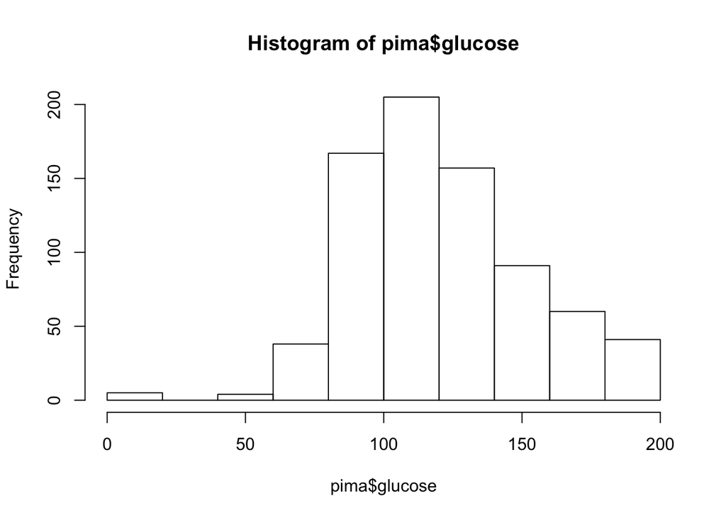

```r
hist(pima$glucose)
```

Note that categorical data should not be numerical, e.g. “test” values.

Variables “glucose”, “diastolic”, “triceps”, “insulin” and “bmi” have minimum value equal to zero. Is it possible to have glucose at zero value level? It seems that zero was used to code missing data. It should not be done because it can cause misleading results because for some variables it can be a valid value.

Set the missing values coded as zero to NA.

```r
pima$glucose[pima$glucose==0] <- NA
pima$diastolic[pima$diastolic==0] <- NA
pima$triceps[pima$triceps==0] <- NA
pima$insulin[pima$insulin==0] <- NA
pima$bmi[pima$bmi==0] <- NA

summary(pima) #summary with number of NA's
```

```
##     pregnant         glucose        diastolic         triceps
##  Min.   : 0.000   Min.   : 44.0   Min.   : 24.00   Min.   : 7.00
##  1st Qu.: 1.000   1st Qu.: 99.0   1st Qu.: 64.00   1st Qu.:22.00
##  Median : 3.000   Median :117.0   Median : 72.00   Median :29.00
##  Mean   : 3.845   Mean   :121.7   Mean   : 72.41   Mean   :29.15
##  3rd Qu.: 6.000   3rd Qu.:141.0   3rd Qu.: 80.00   3rd Qu.:36.00
##  Max.   :17.000   Max.   :199.0   Max.   :122.00   Max.   :99.00
##                   NA's   :5       NA's   :35       NA's   :227
##     insulin            bmi           diabetes           age
##  Min.   : 14.00   Min.   :18.20   Min.   :0.0780   Min.   :21.00
##  1st Qu.: 76.25   1st Qu.:27.50   1st Qu.:0.2437   1st Qu.:24.00
##  Median :125.00   Median :32.30   Median :0.3725   Median :29.00
##  Mean   :155.55   Mean   :32.46   Mean   :0.4719   Mean   :33.24
##  3rd Qu.:190.00   3rd Qu.:36.60   3rd Qu.:0.6262   3rd Qu.:41.00
##  Max.   :846.00   Max.   :67.10   Max.   :2.4200   Max.   :81.00
##  NA's   :374      NA's   :11
##   test
##  neg:500
##  pos:268
##
##
##
##
##
```

At first it is worth to do some graphical exploratory analysis one and more variables. The scatter plot allows one to obtain an overview of the relations between variables.

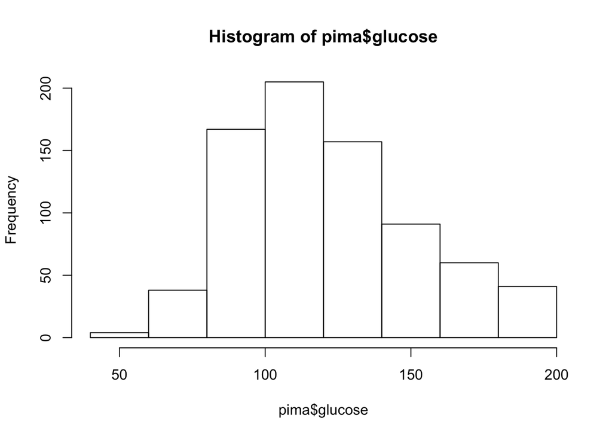

```r
hist(pima$glucose)
```

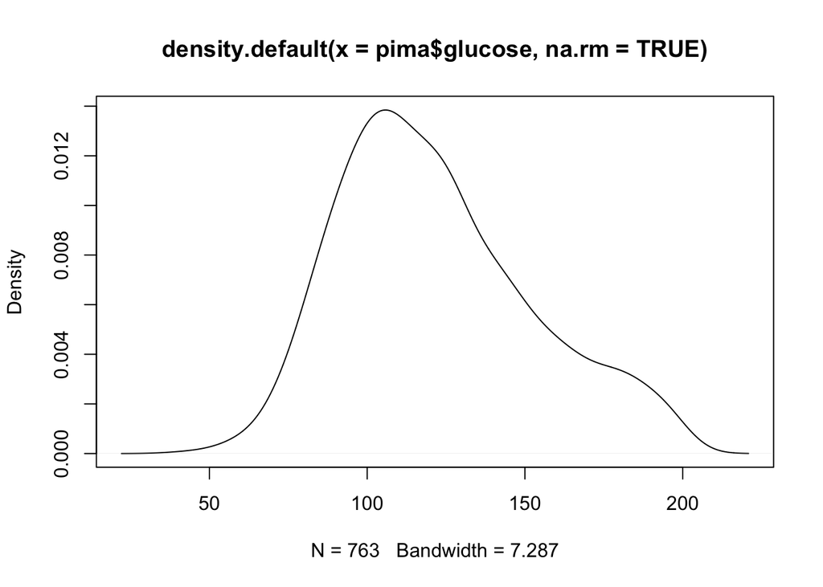

```r
plot(density(pima$glucose,na.rm=TRUE))
```

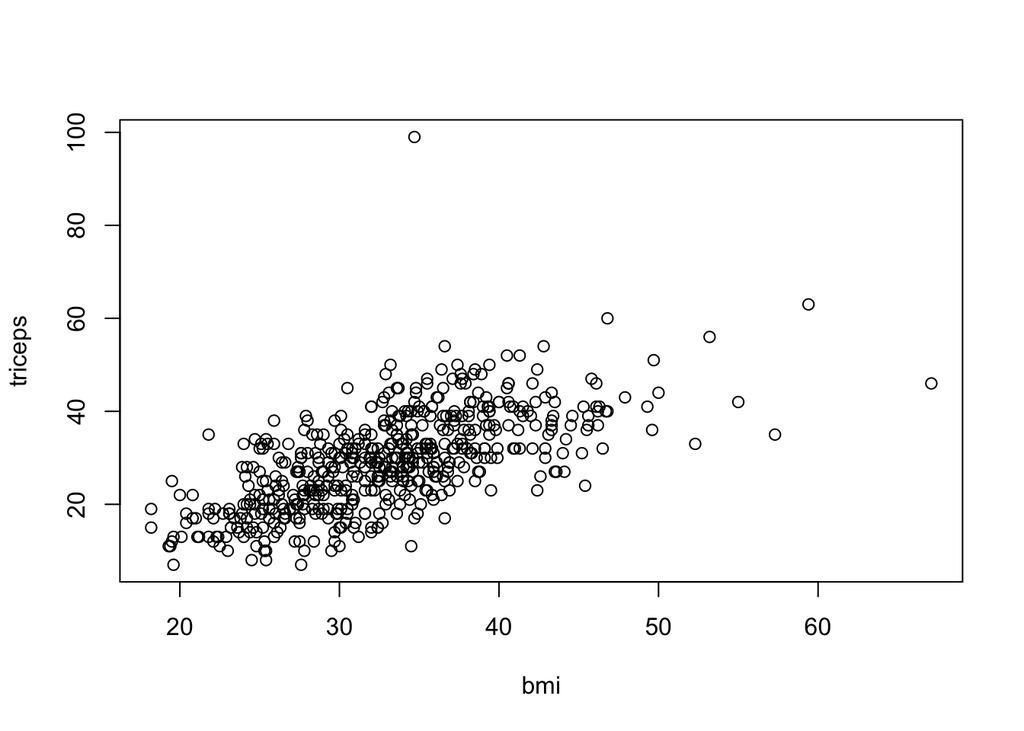

```r
plot(triceps~bmi, pima)
```

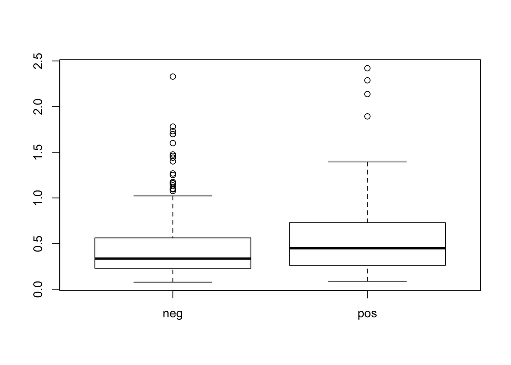

```r
boxplot(diabetes~test ,pima)
```

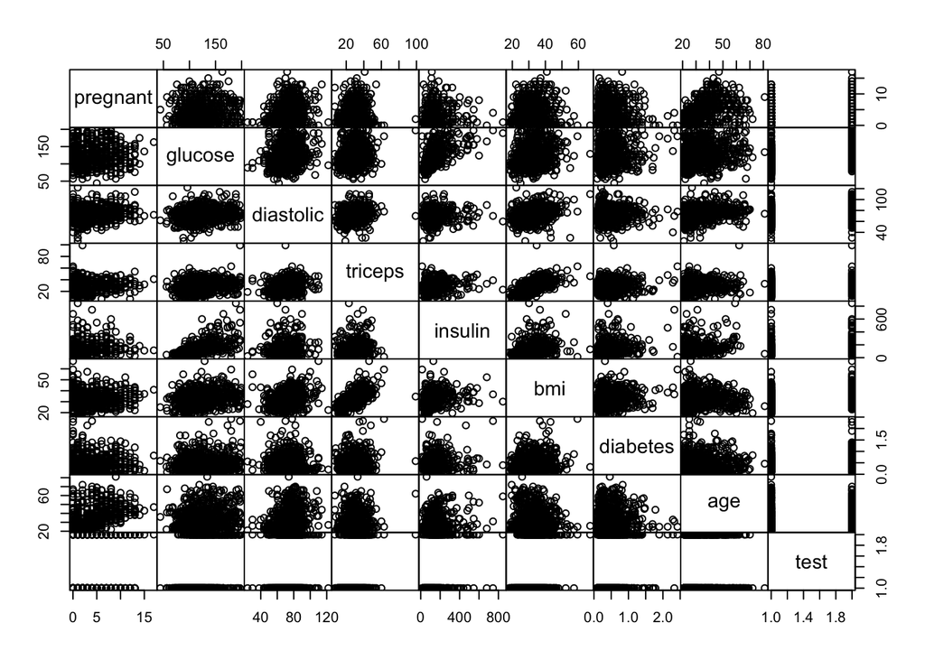

```r
plot(pima, gap=0)
```

Now try a regression. Form the `pairs` plot we can see that there some correlated variables. Fit the regression model using the function `lm()` and use a function `summary()` to get some results.

```r
pima.lm <- lm(glucose~insulin, data= pima)
summary(pima.lm, corr=TRUE)
```

```
##
## Call:
## lm(formula = glucose ~ insulin, data = pima)
##
## Residuals:
##     Min      1Q  Median      3Q     Max
## -65.617 -17.374  -5.745  12.557  78.790
##
## Coefficients:
##             Estimate Std. Error t value Pr(>|t|)
## (Intercept) 99.09805    2.09240   47.36   <2e-16 ***
## insulin      0.15087    0.01068   14.12   <2e-16 ***
## ---
## Signif. codes:  0 '***' 0.001 '**' 0.01 '*' 0.05 '.' 0.1 ' ' 1
##
## Residual standard error: 25.11 on 391 degrees of freedom
##   (375 observations deleted due to missingness)
## Multiple R-squared:  0.3378, Adjusted R-squared:  0.3361
## F-statistic: 199.4 on 1 and 391 DF,  p-value: < 2.2e-16
##
## Correlation of Coefficients:
##         (Intercept)
## insulin -0.80
```

`Intercept` is a free coefficient $\beta_0$.

# Regression excersices

Now we will use an excersice from ISRL book. When you write `?Boston` in R console, you will see a decsription of the dataset.

```r
library(MASS)
data(Boston)
head(Boston)
```

```
##      crim zn indus chas   nox    rm  age    dis rad tax ptratio  black
## 1 0.00632 18  2.31    0 0.538 6.575 65.2 4.0900   1 296    15.3 396.90
## 2 0.02731  0  7.07    0 0.469 6.421 78.9 4.9671   2 242    17.8 396.90
## 3 0.02729  0  7.07    0 0.469 7.185 61.1 4.9671   2 242    17.8 392.83
## 4 0.03237  0  2.18    0 0.458 6.998 45.8 6.0622   3 222    18.7 394.63
## 5 0.06905  0  2.18    0 0.458 7.147 54.2 6.0622   3 222    18.7 396.90
## 6 0.02985  0  2.18    0 0.458 6.430 58.7 6.0622   3 222    18.7 394.12
##   lstat medv
## 1  4.98 24.0
## 2  9.14 21.6
## 3  4.03 34.7
## 4  2.94 33.4
## 5  5.33 36.2
## 6  5.21 28.7
```

Please do some exploratory analysis of this dataset: summaries, plots, e.g. the range of `medv` column and its quantiles.

We will seek to predict `medv` (median house value) using 13 predictors such as `rm` (average number of rooms per house), `age` (average age of houses), and `lstat` (percent of households with low socioeconomic status).

```r
lm.fit=lm(medv~lstat ,data=Boston)
#Short information
lm.fit
```

```
##
## Call:
## lm(formula = medv ~ lstat, data = Boston)
##
## Coefficients:
## (Intercept)        lstat
##       34.55        -0.95
```

```r
summary(lm.fit)
```

```
##
## Call:
## lm(formula = medv ~ lstat, data = Boston)
##
## Residuals:
##     Min      1Q  Median      3Q     Max
## -15.168  -3.990  -1.318   2.034  24.500
##
## Coefficients:
##             Estimate Std. Error t value Pr(>|t|)
## (Intercept) 34.55384    0.56263   61.41   <2e-16 ***
## lstat       -0.95005    0.03873  -24.53   <2e-16 ***
## ---
## Signif. codes:  0 '***' 0.001 '**' 0.01 '*' 0.05 '.' 0.1 ' ' 1
##
## Residual standard error: 6.216 on 504 degrees of freedom
## Multiple R-squared:  0.5441, Adjusted R-squared:  0.5432
## F-statistic: 601.6 on 1 and 504 DF,  p-value: < 2.2e-16
```

As you can see `summary` will give us an information about p- values and standard errors for the coefficients, as well as the R2 statistic and F-statistic for the model.  
In a simple linear regression setting, in order to determine whether there is a relationship between the response and the predictor we can simply check whether $\beta_1 = 0$. In the multiple regression setting with p predictors, we need to ask whether all of the regression coefficients are zero, i.e. whether $\beta_1 = \beta_2 = ··· = \beta_p = 0$. As in the simple linear regression setting, we use a hypothesis test to answer this question. We test the null hypothesis,

$H_0 : \beta_1 = \beta_2 = ··· = \beta_p = 0$ (There is no relationship between variables)

versus the alternative (There is any relationship) $H_a$ : at least one $\beta_j$ is non-zero. This hypothesis test is performed by computing the F-statistic and p-value.

If you want to see confidence intervals for regression parameters, just write:

```r
confint.lm(lm.fit)
```

```
##                 2.5 %     97.5 %
## (Intercept) 33.448457 35.6592247
## lstat       -1.026148 -0.8739505
```

Now we will try some predictions:

```r
predict(lm.fit,data.frame(lstat=c(5,10,15)), interval ="confidence")
```

```
##        fit      lwr      upr
## 1 29.80359 29.00741 30.59978
## 2 25.05335 24.47413 25.63256
## 3 20.30310 19.73159 20.87461
```

```r
predict(lm.fit,data.frame(lstat=c(5,10,15)), interval ="prediction")
```

```
##        fit       lwr      upr
## 1 29.80359 17.565675 42.04151
## 2 25.05335 12.827626 37.27907
## 3 20.30310  8.077742 32.52846
```

For instance, the 95 % confidence interval associated with a lstat value of 10 is (24.47, 25.63), and the 95 % prediction interval is (12.828, 37.28).

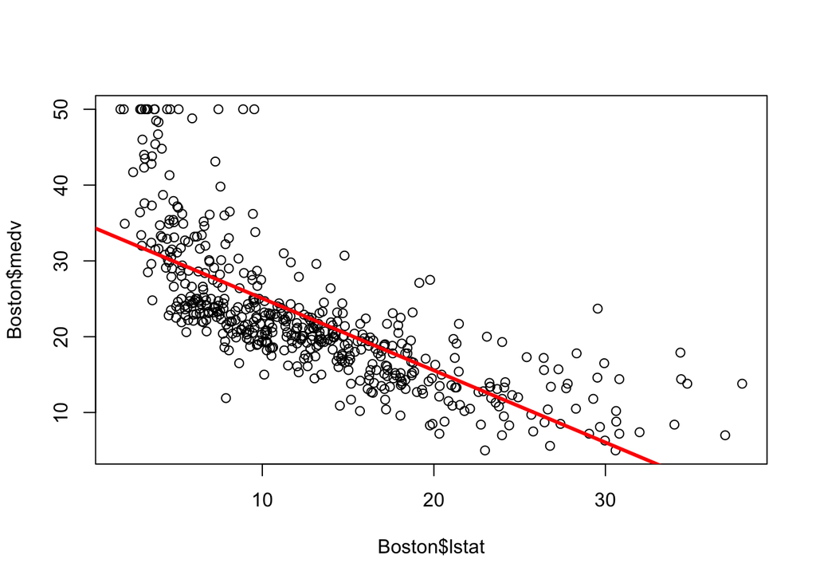

```r
plot(Boston$lstat ,Boston$medv)
#or use attach(Boston) and then use only names of variables plot(lstat, medv)

abline(lm.fit,lwd=3,col="red")
```

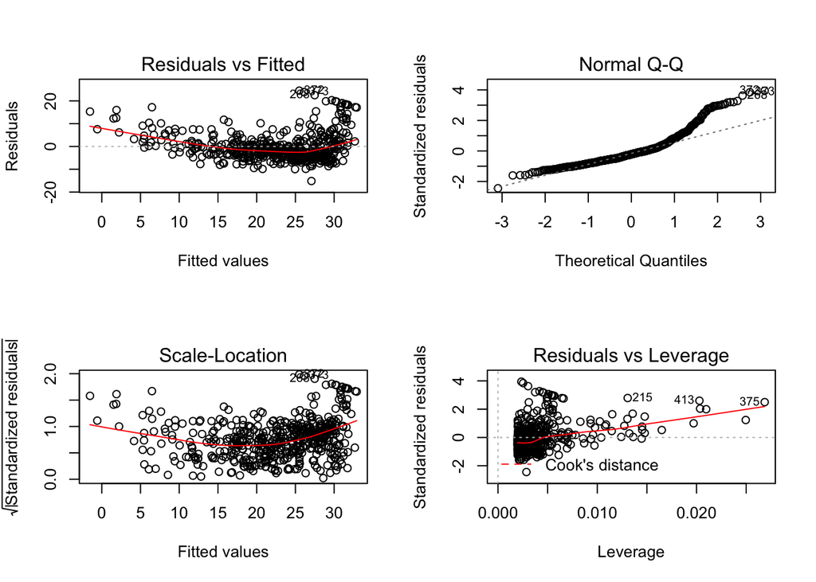

```r
par(mfrow=c(2,2))
plot(lm.fit)
```

[output not shown]

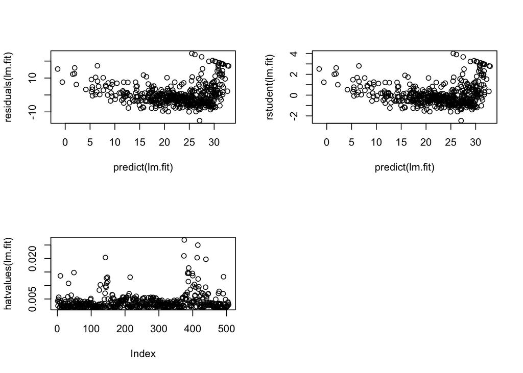

```r
plot(predict(lm.fit), residuals(lm.fit))
plot(predict(lm.fit), rstudent(lm.fit))
plot(hatvalues(lm.fit))
which.max(hatvalues (lm.fit))
```

```r
lm.fit=lm(medv~lstat+age,data=Boston)
summary(lm.fit)
```

```
##
## Call:
## lm(formula = medv ~ lstat + age, data = Boston)
##
## Residuals:
##     Min      1Q  Median      3Q     Max
## -15.981  -3.978  -1.283   1.968  23.158
##
## Coefficients:
##             Estimate Std. Error t value Pr(>|t|)
## (Intercept) 33.22276    0.73085  45.458  < 2e-16 ***
## lstat       -1.03207    0.04819 -21.416  < 2e-16 ***
## age          0.03454    0.01223   2.826  0.00491 **
## ---
## Signif. codes:  0 '***' 0.001 '**' 0.01 '*' 0.05 '.' 0.1 ' ' 1
##
## Residual standard error: 6.173 on 503 degrees of freedom
## Multiple R-squared:  0.5513, Adjusted R-squared:  0.5495
## F-statistic:   309 on 2 and 503 DF,  p-value: < 2.2e-16
```

You can use also formluas such as `medv~.` for all variables in the dataset, `medv~.-age` for all but one variables or even you can do non linear fitting with formulas: `medv ∼ lstat * age`, `medv∼lstat+I(lstat^2)`, `medv ∼ poly(lstat,5)`, `medv~log(rm)`.

```r
lm.fit=lm(medv~lstat,data=Boston)
lm.fit2=lm(medv~lstat+I(lstat^2), data=Boston)
anova(lm.fit ,lm.fit2)
```

```
## Analysis of Variance Table
##
## Model 1: medv ~ lstat
## Model 2: medv ~ lstat + I(lstat^2)
##   Res.Df   RSS Df Sum of Sq     F    Pr(>F)
## 1    504 19472
## 2    503 15347  1    4125.1 135.2 < 2.2e-16 ***
## ---
## Signif. codes:  0 '***' 0.001 '**' 0.01 '*' 0.05 '.' 0.1 ' ' 1
```

The `anova()` function performs a hypothesis test comparing the two models. The null hypothesis is that the two models fit the data equally well, and the alternative hypothesis is that the full model is superior. Here the F-statistic is 135 and the associated p-value is virtually zero. This provides very clear evidence that the model containing the predictors `lstat` and `lstat2` is far superior to the model that only contains the predictor `lstat`. This is not surprising, since earlier we saw evidence for non-linearity in the relationship between `medv` and `lstat`.

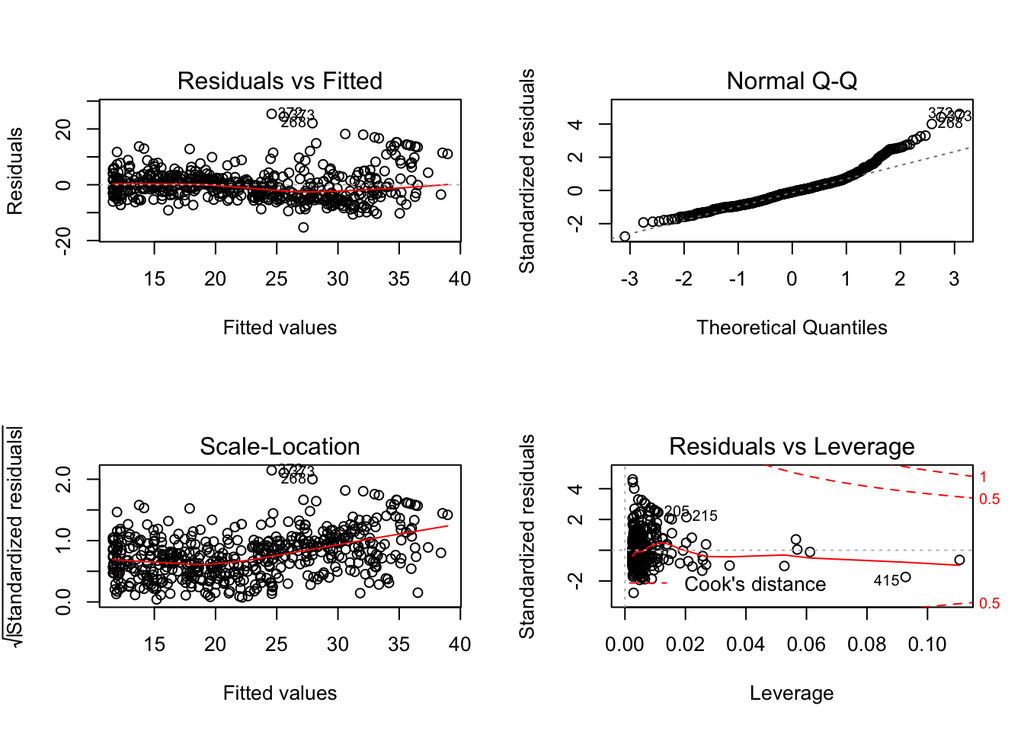

```r
par(mfrow=c(2,2))
plot(lm.fit2)
```